# Social Group Appeals and Affective Polarization in Western Europe

Will Horne

Clemson University

Alona O. Dolinsky

University of Birmingham

Lena Maria Huber

MZES, University of Mannheim

James Adams

University of California, Davis

2026-09-04

# Two accounts of partisan dislike

> *Parties don’t just take positions: they stand **for** and **against** social groups.*
- **Policy account:** partisans dislike parties that are *ideologically distant* (Gidron, Adams & Horne 2023)
- **Identity account:** dislike is rooted in *who partisans think the parties are for* (Mason 2018; Huddy et al. 2018)
- Comparative work has tested the policy account, because positional data exist. The identity account has lacked data.

**Our question.** When two parties talk about social groups differently, do their supporters dislike each other’s party more, *beyond* what ideological distance explains?

# This paper

Data

**PSoGA** manifesto appeals + **CSES** party ratings: 186,194 respondent–party evaluations across 33 elections, eight West European countries, 1996–2021.

Measure

**Rhetorical distance**: each party-election is a vector of positive and negative appeal shares over 43 groups; distance = how differently two parties talk about people.

Design

**Within-voter.** Respondent fixed effects: one voter comparing the parties on her own ballot

**Preview:** rhetorical distance predicts out-party dislike; strongest among appeals directed at *cultural* groups, particularly *negative* appeals.

# Measurement: Group Appeals Models

**Per manifesto sentence:**

1. *Groups mentioned* (token classifier)
2. *Stance* positive / negative / neutral
3. *Policy directed at the group?*
4. *Category* (43 + Other, multi-label)

Four fine-tuned mDeBERTa-v3 models, trained on 7,589 hand-coded sentences, validated in 8 languages (F1 0.80–0.92).

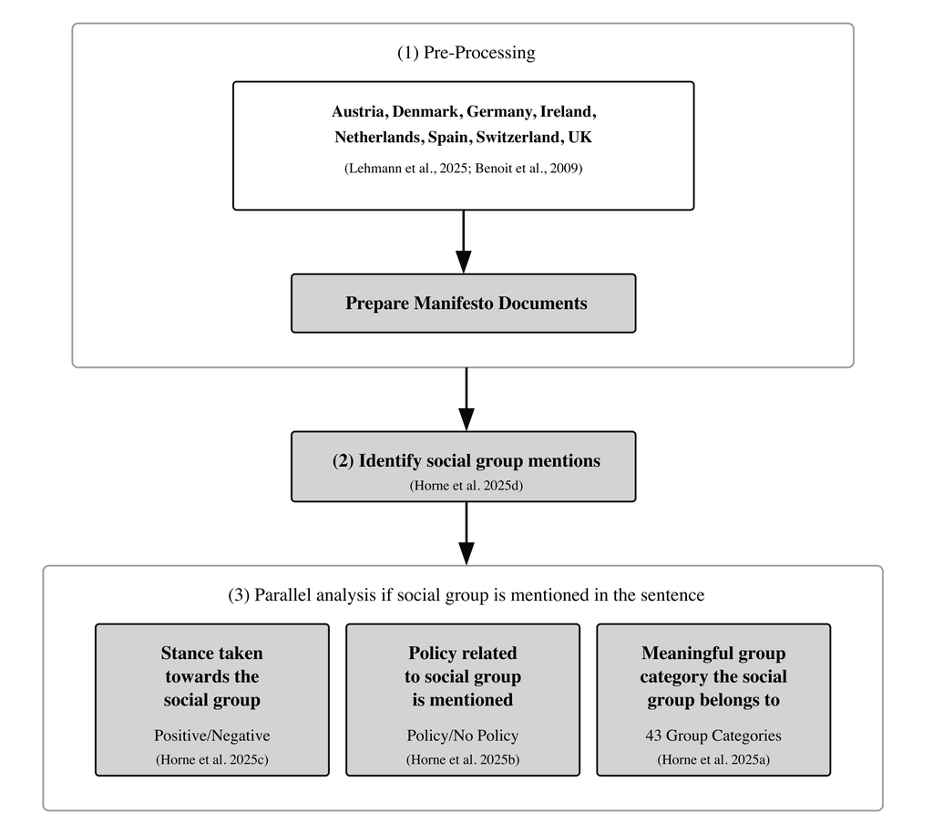

# The PSoGA Database

791

manifestos

139

parties

8

countries

1970–2025

55 years

- **~304K group mentions** — every one with stance, policy flag, and category
- 71.5% positive · 8.4% negative · 20.1% neutral
- Manifesto-level shares merge directly with MARPOR, CHES, CSES

**Countries:** Austria, Denmark, Germany, Ireland, Netherlands, Spain, Switzerland, UK

Dolinsky, Huber & Horne (2026), *BJPS*. Open on Harvard Dataverse.

# Measuring *rhetorical distance*

- Party = vector of **positive and negative appeal shares** per group (% of coded content)
- **Euclidean distance, within election**

Robust to alternative measurements like netting rhetoric, cosine similarity, specific groups, length filter.

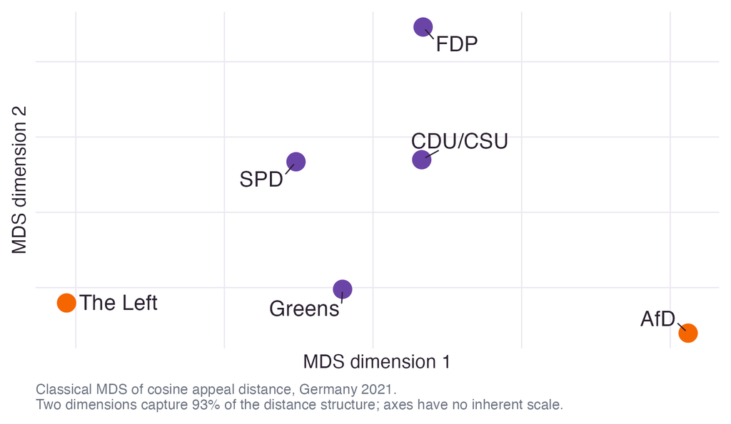

# Design: one voter’s ballot

186,194

out-party ratings

47,764

voters w/ in-party

867

party pairs

33

elections

- Outcome: CSES **0–10 like–dislike** rating of each out-party; in-party = vote choice (robust to party ID)
- **Respondent fixed effects**: identification from one voter comparing the parties in her choice set: absorbs demographics, ideology, baseline warmth, country-year specific context
- Controls: **expert-coded** left–right and GAL–TAN distance (CHES)
- SEs two-way clustered (party-election, respondent); manifestos ≥ 50 coded sentences

# Distance predicts dislike

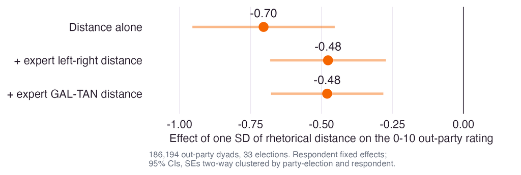

Across the 867 estimation pairs, rhetorical distance correlates just r = .18 with expert left–right and .06 with GAL–TAN

# Cultural, not economic

[figure not shown]

Not for lack of variation: parties diverge as much on economic groups. Economic appeal distance is largely *absorbed by left–right*; cultural distance survives GAL–TAN too: it is not entirely the expert cultural dimension.

# Hostility matters most

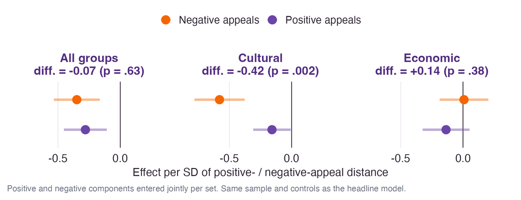

# The Target Matters

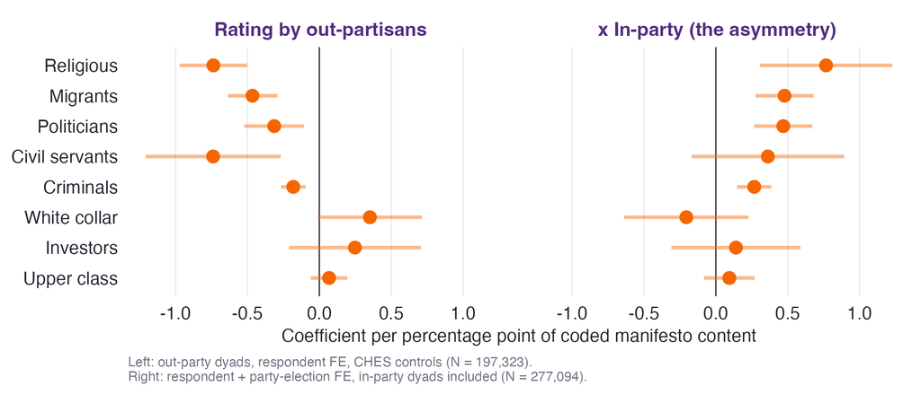

# Who responds? The attentive

[figure not shown]

Steeper among the educated and politically informed: consistent with a mechanism that runs through voters *registering what parties say*.

# Take-aways

A distinct dimension

Group-appeal distance predicts partisan affect **beyond** left–right and GAL–TAN: elite conflict that ideological/issue position scales don’t measure.

Boundary Policing

Hostile talk about *identity-relevant communities* is associated with polarization.

Infrastructure

PSoGA + models avaialable for others to use. PSoGA = Dataverse, Models = HuggingFace or Python Package `GroupAppeals`

**Elites polarize publics not only by moving apart on issues, but by speaking differently about the people who make up the polity.**

**Thank you.** *rwhorne@clemson.edu* · PSoGA: Harvard Dataverse · Paper draft available